# Are number of Russian Tourists related to CPI, Exchange Rates USD/TL and RUB/TL?

Muhammet Enes Üstün - IE360 - Spring 2021

15.04.2021

In this homework, I have tried to find an answer to the question “Are number of Russian Tourists related to Consumer Price Index, Exchange Rates USD/TL and RUB/TL. The statistics are gathered from CBRT’s Electronic Data Delivery System. The observations are sampled monthly. 36 months of data is used corresponding to 01/2017 - 12/2019. Also data of average daily search number of”Antalya" word from Russia region and “Dolar kaç TL?” from Turkey region was gathered from Google Trends.

```r
exportdata=read.xlsx("RUS_DATA.xlsx",sheet='EVDS')
```

# PART A

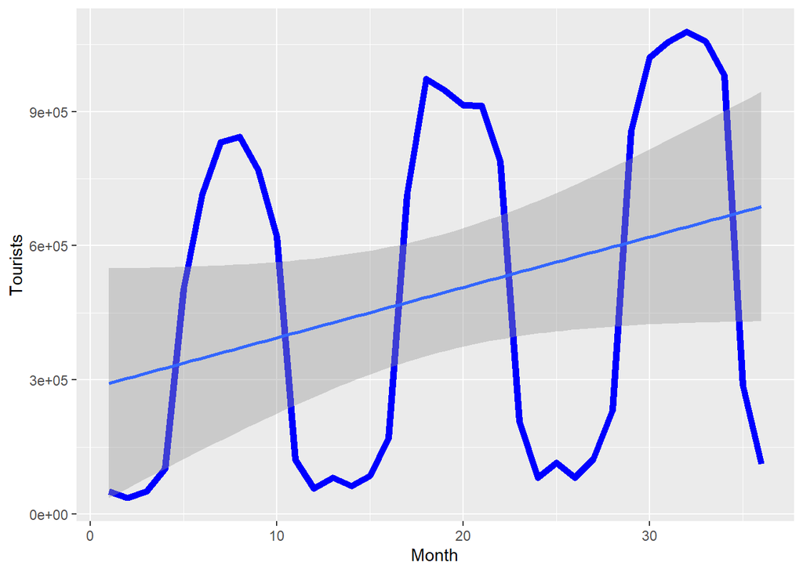

```r
ggplot(exportdata, aes(Month, Tourists))+geom_line(col="blue", size=2) + geom_smooth(method = "lm")
```

When I plot the number of tourists, it can be observed that line is cylic and increases at summer seasons and decreases on winters. Overall level of number is increasing from 2017 to 2019. One answer can be that Russian tourists prefer to have a vacation in Turkey in summers because Turkey has coasts at Mediterranian unlike Russia.

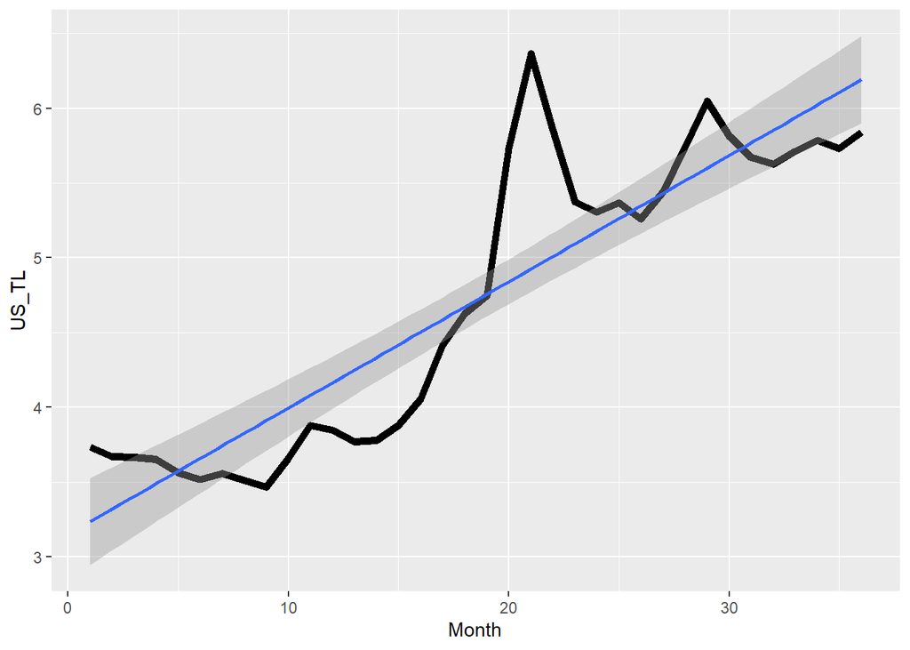

```r
ggplot(exportdata, aes(Month, US_TL))+geom_line(col="black", size=2) + geom_smooth(method = "lm")
```

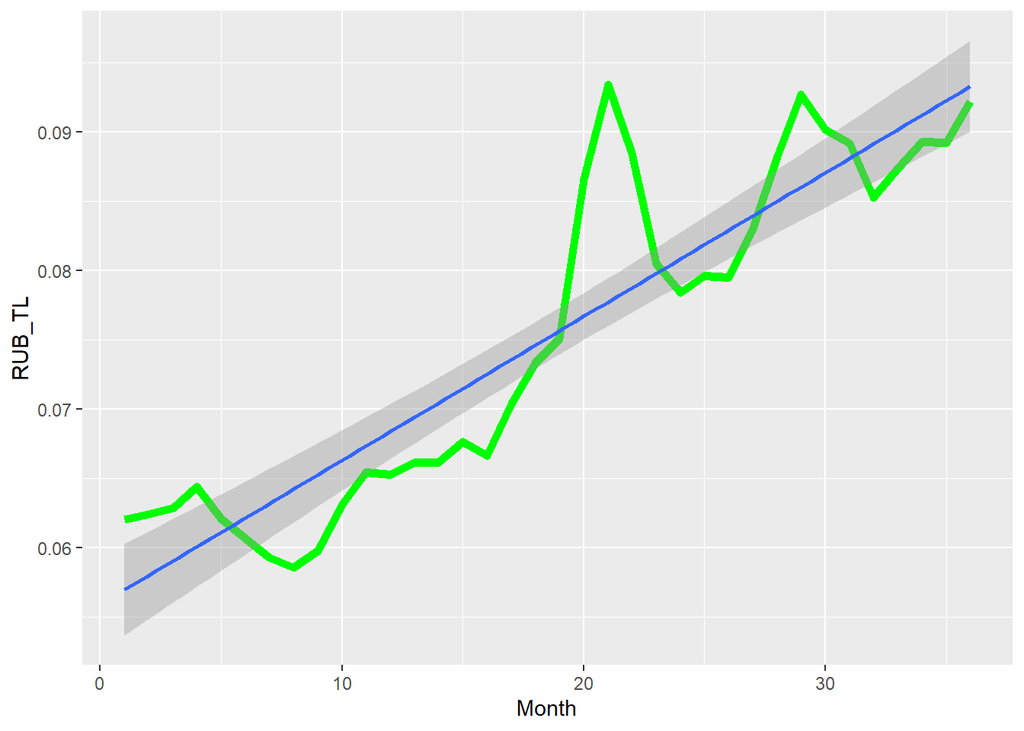

```r
ggplot(exportdata, aes(Month, RUB_TL))+geom_line(col="green", size=2) + geom_smooth(method = "lm")
```

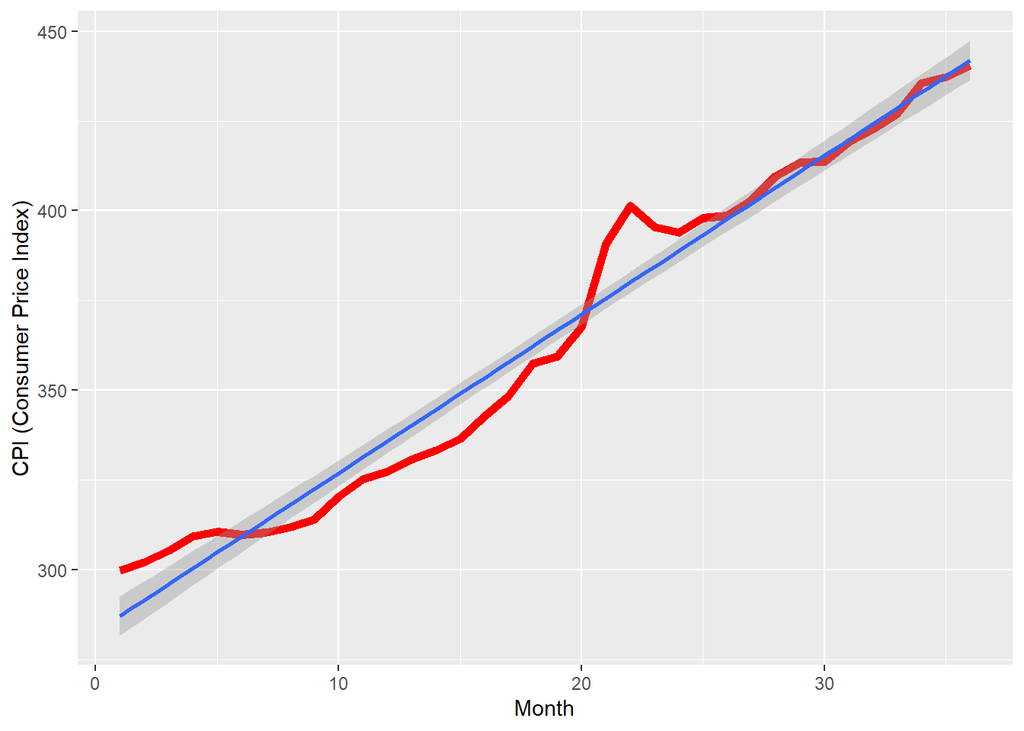

```r
ggplot(exportdata, aes(Month, PriceIndex))+geom_line(col="red", size=2) + geom_smooth(method = "lm")+ylab("CPI (Consumer Price Index)")
```

# PART B

## Number of Tourists from Russia vs. Search of Antalya from Russia

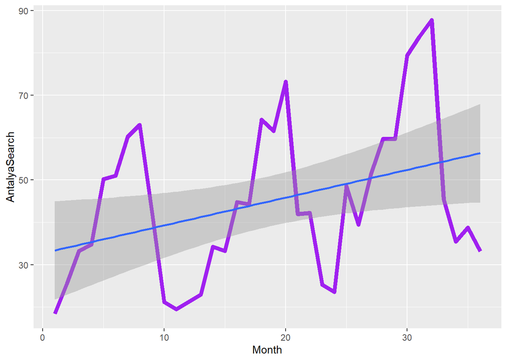

```r
ggplot(exportdata, aes(Month, AntalyaSearch))+geom_line(col="purple", size=2) + geom_smooth(method = "lm")
```

Here is the average daily search of the word “Antalya” from Russia Federation in the period of 01.2017 - 12.2019. I pick this word because Antalya is the first preference of Russian tourists in Turkey. It follows an increasing trend with yearly similar fluctuations.

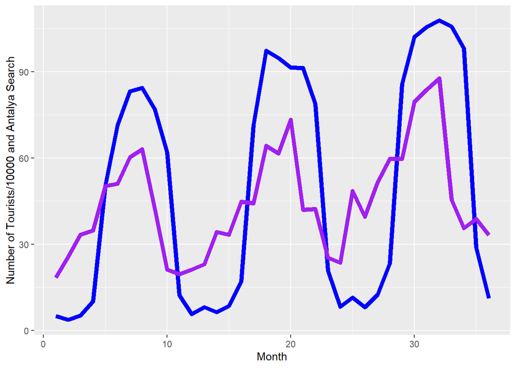

```r
ggplot(exportdata,aes(Month,Tourists/10000))+geom_line(color="blue", size=2)+geom_line(aes(Month,AntalyaSearch),color="purple",size=2)+labs(y="Number of Tourists/10000 and Antalya Search")
```

What happens in number of tourists, it is also happening in the search of word “Antalya from Russia region. Both number of Russian tourists and”Antalya" searches highly correlated and follow an increasing trend with yearly fluctuations.

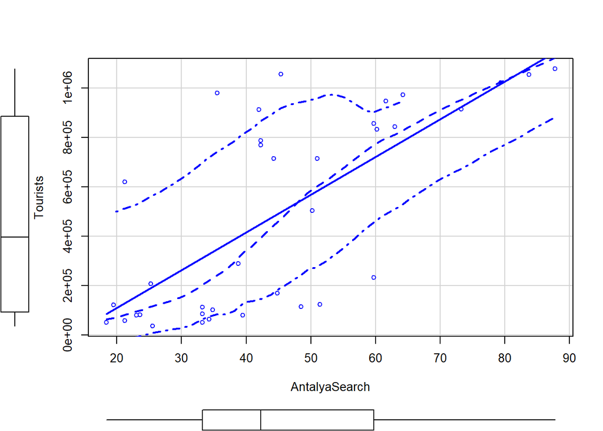

```r
scatterplot(Tourists ~ AntalyaSearch, data = exportdata)
```

Here is the scatter plot of number of tourists and search trends. Somehow linear relation can be observed.

## USD/TL Exchange Rate vs. Search of ‘Dolar kaç TL?’ from Turkey

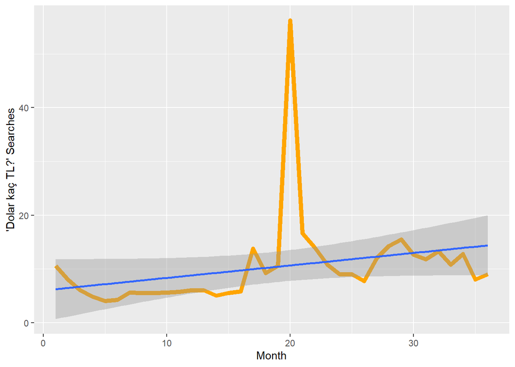

```r
ggplot(exportdata, aes(Month, DollarSearch))+geom_line(col="orange", size=2) + geom_smooth(method = "lm")+ylab("'Dolar kaç TL?' Searches")
```

What here is the average daily search of “Dolar kaç TL?” from Turkey in the monthly period of 01.2017 - 12.2019.

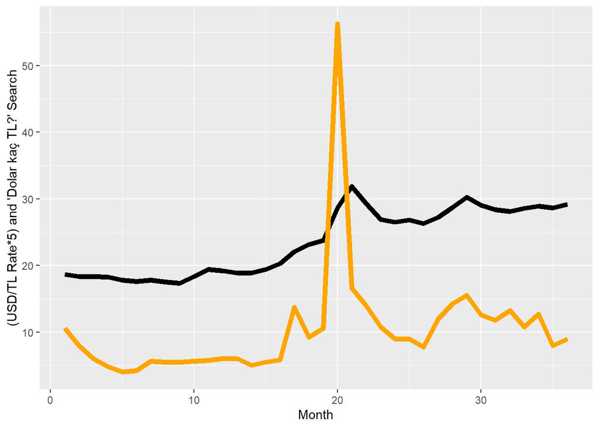

```r
ggplot(exportdata,aes(Month,US_TL*5))+geom_line(color="black", size=2)+geom_line(aes(Month,DollarSearch),color="orange",size=2)+ylab("(USD/TL Rate*5) and 'Dolar kaç TL?' Search")+ scale_color_discrete(name = "Y series", labels = c("Y2", "Y1"))
```

This plot explains the behavior at Aug 2018 which USD/TL broke its own record. Average daily search of “Dolar kaç TL?” is very high at that month.

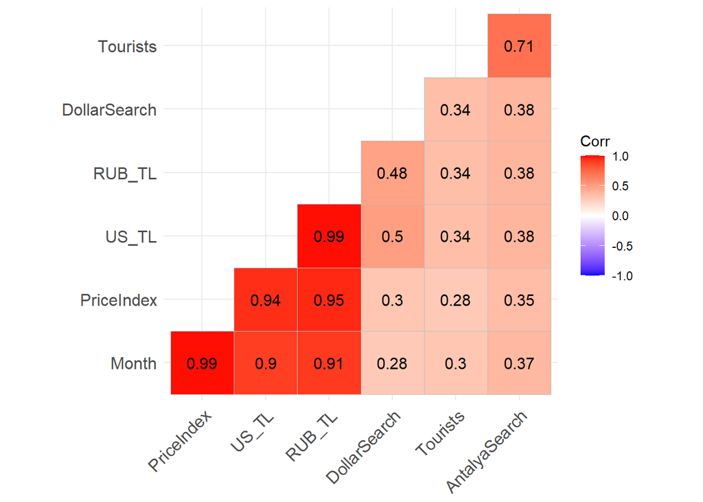

```r
correl_info=cor(exportdata)
ggcorrplot(correl_info,
           hc.order = TRUE,
           type = "lower",
           lab = TRUE)
```

Here is the correlation between variables. USD/TL, RUB/TL and CPI are somehow related to Number of Russian Tourists visited Turkey. I was expecting that CPI is negatively correlated with Tourist number but it has least correlation with Tourists. Average daily search of the word “Antalya” is highly positively correlated with number of tourists. Also average daily search of “Dolar kaç TL?” is positively correlated with USD/TL exchange rate.

## References and Notes

1. [Google Trend Data of “Antalya” Searches](https://trends.google.com/trends/explore?date=2017-01-01%202019-12-31&geo=RU&q=antalya)

AntalyaSearch -> Average daily search of “Antalya” word from Russia region in terms of months between 01.2017-12.2019

2. [Google Trend Data of “Dolar kaç TL?” Searches](https://trends.google.com/trends/explore?date=2017-01-01%202019-12-31&geo=TR&q=dolar%20ka%C3%A7%20tl)

DollarSearch -> Average daily search of “Dolar kaç TL?” from Turkey region in terms of months between 01.2017-12.2019

3. [EVDS Page of CBRT’S Website](https://evds2.tcmb.gov.tr/index.php?/evds/serieMarket)

### Series Description

Tourists -> TP.ODEMGZS.RUSYA Milliyetlere Göre Ziyaretçi Sayısı__RUSYA-Düzey Gözlem Değeri: Kümülatif

US_TL -> TP.DK.USD.A.YTL (USD) ABD Doları (Döviz Alış)-Düzey Gözlem Değeri: Orijinal Gözlem

RUB_TL -> TP.DK.RUB.A.YTL (RUB) Rus Rublesi (Döviz Alış)-Düzey Gözlem Değeri: Orijinal Gözlem

PriceIndex -> TP.FG.J0 0.GENEL-Düzey Gözlem Değeri: Orijinal Gözlem

### Notes

TP.ODEMGZS.RUSYA Data Source MINISTRY OF CULTURE AND TOURISM

[Uygulama Değişiklik Linki](http://www.tcmb.gov.tr/wps/wcm/connect/TR/TCMB+TR/Main+Menu/Istatistikler/Odemeler+Dengesi+ve+Ilgili+Istatistikler/Odemeler+Dengesi+Istatistikleri/Uygulama+Test/)

[Veri Yayınlama Takvim Linki](http://www3.tcmb.gov.tr/veriyaytakvim/takvim.php)

[Metaveri Linki](http://www.tcmb.gov.tr/wps/wcm/connect/0ab87526-c290-4bdd-94d4-b8e99e70eba9/BOPMetaveri.pdf?MOD=AJPERES&CACHEID=ROOTWORKSPACE-0ab87526-c290-4bdd-94d4-b8e99e70eba9-mcFYR7h)

[Revizyon Politika Linki](http://www.tcmb.gov.tr/wps/wcm/connect/6f18f19b-17c7-43cb-8c80-55b5fb4c67f4/RevizyonPolitikas%C4%B1.pdf?MOD=AJPERES&CACHEID=ROOTWORKSPACE-6f18f19b-17c7-43cb-8c80-55b5fb4c67f4-m5h8na2)

TP.DK.USD.A.YTL Data Source CBRT

TP.DK.RUB.A.YTL Data Source CBRT

TP.FG.J0 Data Source TURKISH STATISTICAL INSTITUTE

[Uygulama Değişiklik Linki](http://www.tuik.gov.tr/PreTablo.do?alt_id=114)

[Veri Yayınlama Takvim Linki](http://www.tuik.gov.tr/takvim/tkvim.zul#tb1)

[Metaveri Linki](http://www.tuik.gov.tr/PreTablo.do?alt_id=114)

[Revizyon Politika Linki](http://www.tuik.gov.tr/PreTablo.do?alt_id=114)